# Creating your own package

Maria Kubara, based on materials by prof. Piotr Wójcik

Let’s install and load the necessary packages:

```r
install.packages("devtools")
install.packages("roxygen2")
```

```r
library(devtools)
library(pkgbuild)
library(roxygen2)
```

We check if Rtools are installed

```r
pkgbuild::find_rtools()
```

```
## [1] TRUE
```

> CAUTION! Since version 2.0.0 of the devtools package significant changes have occurred in building packages.

> See:

> [devtools-2-0-0](https://www.tidyverse.org/articles/2018/10/devtools-2-0-0/)

> [devtools.r-lib.org](https://devtools.r-lib.org/)

## Introduction

“Packages are the basic elements of a reproducible R code.” (Hadley Wickham, “R Packages”).

In our daily work as programmers/analysts, we create many functions that make it easier to perform repetitive tasks. We save them in separate files, which we then load using the command `source()`.

However, you need to remember where the file containing the needed function is saved, what arguments a function requires, what it is used for. If other people also use function created by us, it must be clearly described and commented.

A great way to organize, document and share our functions with others is to combine them in a package.

Importantly, when creating your own package you do not have to immediately assume that it should be perfect and meet all the requirements set by CRAN. Our package may never hit CRAN, but one can make it available e.g. on the Github website. We can also create a package just to organize our own function repository, without intending to share it with anyone else.

Creating the package seems to be a difficult and complicated task, available only to advanced programmers, software developers.

That was a few years ago. Today?

Today it can be created by anyone can who knows how to:

- open R and RStudio,
- install an additional package
- write a function in R and describe it briefly

Today there are many tools available that make creating your own package a task available to every intermediate R user.

The description below and its main source are inspired by Susan Johnston’s presentation: [“Writing R Packages from scratch using RStudio & roxygen2”](https://github.com/EdinbR/edinbr-talks/blob/master/2018-01-17/Writing_R_Packages_from_Scratch_v2_annotated.pdf) and a post on the blog `Methods.blog` pt: [A Quickstart Guide for Building Your First R Package](https://methodsblog.wordpress.com/2015/11/30/building-your-first-r-package/).

## What does the package consist of?

A package is a directory with files and subdirectories with strictly defined contents:

- file `DESCRIPTION` containing metadata – description of basic information about the package (package name, short description, author, dependencies) – [more information](http://r-pkgs.had.co.nz/description.html),
- file `NAMESPACE` containing a list of functions provided by the package and possible dependencies on other packages – [more information](https://cran.r-project.org/web/packages/roxygen2/vignettes/namespace.html)
- folder `R` containing R code files with package functions,
- folder `man` containing documentation files in the Rd format for shared objects (functions and data sets),
- folder `data` containing a list of data sets provided by the package,
- folder `vignettes` with a list of guides describing the functionalities of the package,
- folder `demo`, with sample codes – similar to the examples in the function documentation, but usually longer and based on more than one function.
- folder `tests`, with a list of tests verifying the correctness of the functions.

An example of the package diagram is shown in the following figure:

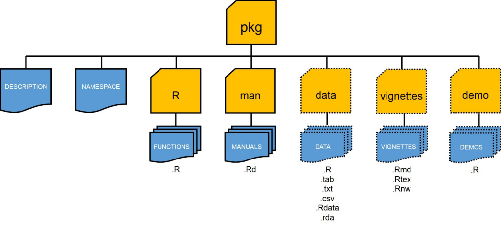

Package structure

## Creating the package step by step

Below we show in a few steps how to create your first package using the package `devtools` and `roxygen2`. The steps include:

1. installation of appropriate tools
2. creating the package skeleton
3. adding/editing `.R` files with functions
4. adding/editing `roxygen2` code blocks in function files
5. creating `.Rd` files with documentation and the `NAMESPACE` file
6. editing of the package description file (`DESCRIPTION`)
7. package validity verification
8. repeat steps 3–7 if necessary
9. creating a package
10. package installation

The next optional stage may be the dissemination/publication of the package.

Let’s briefly discuss individual steps from the above list.

### 1. installation of appropriate tools

Similarly to using C++ in R, creating packages requires the installation of additional tools. On Windows, this means that the latest version of `Rtools` needs to be installed, on the Mac the `Xcode` application from AppStore, and on Linux the `r-base-dev` package or similar.

You will also need to install packages `devtools`, `pkgbuild` and `roxygen2`.

### 2. creating the package skeleton

Creating a new package can be started with the command `create_package()` from the package usethis with the indication of its name and location using the argument path = `"path/to/package/package_name"`. The last element of the provided path is treated as the package name. It has some restrictions – it can only consist of letters belonging to the ASCII encoding (i.e. Latin alphabet, letters without special characters), numbers or periods (dots), must have at least two characters, begin with a letter and must NOT end with a period (dot). If we give only the package name as the `path` argument, the corresponding folder will be created in the default path.

Let’s assume that our package will be called `MyFirstPackage`:

```r
create_package(path = "path/to/package/MyFirstPackage")
```

For now, the only folder created as part of the package is `R` (empty). In addition, we have the files `NAMESPACE` and `DESCRIPTION`, as well as the configuration file of the RStudio project `MyFirstPackage.Rproj`.

This is the skeleton of our package. The most important element which is still missing is the `man` folder containing the package documentation – we will create it in a moment automatically with the help of the `roxygen2` package.

### 3. adding/editing `.R` files with functions

The next stage of creating a package is filling it with content. The most important content of the package are functions – their place is in the folder `R`. We just need to create/copy there our files with the extension `.R` containing the functions that make up the package. It is a good practice to put each function in a separate file whose name will match the name of the function. However, this is not necessary – the file name does not have to match the function name. What’s more, you can include any number of functions in one file.

### 4. adding/editing `roxygen2` code blocks in function files

After adding the functions to the package one has to create their documentation that will be available to users of the package. Function documentation in many publicly available packages on CRAN is quite laconic, which is however not a good practice. It is worth describing the function, its arguments and results in a way that we would like to see ourselves in the descriptions of functions that we use – legibly, comprehensively and with adequate examples.

For documentation R uses the files with the extension `.Rd` in the `man` directory – they are NOT automatically created when creating the package skeleton. The `.Rd` files use a specific syntax, loosely based on the `LaTeX` language, and are converted to `HTML`, plain text and pdf.

Fortunately, there is no need to create these files manually. The `roxygen2` package comes in handy and allows to generate the appropriate `.Rd` files by transforming specially formatted comments added in the files with the function code. Special formatting of comments consists primarily in starting them with a combination of `#'` characters and adding the tags described below. In addition to generating documentation files, the `roxygen2` package also allows you to automatically manage the contents of the `NAMESPACE` file.

Function documentation **MUST** contain the following fields:

- `Name`: document name (added automatically by `roxygen2`)
- `Alias`: name of the documented function (added automatically by `roxygen2`)
- `Title`: documentation header (first line of the `roxygen2` block in the function code)
- `Usage`: list of arguments and their default values (added automatically by `roxygen2`)
- `Arguments`: description of individual arguments of the function (added automatically by `roxygen2` based on the line with the tag `@param` in the function code)
- `Description`: Short description of the package operation (third line of the `roxygen2` block in the function code)

Function documentation **SHOULD** contain the following fields:

- `Value`: information on what the function returns (automatically added by `roxygen2` based on the line with the `@return` tag in the function code)
- `Details`: a detailed description of how the function is used (automatically added by `roxygen2` based on the line with the `@details` tag in the function code)
- `Examples`: examples of using the function (added automatically by `roxygen2` based on the line with the @examples tag in the function code)

Function documentation **CAN** contain the following fields:

- `Author`: author(s) of the function (automatically added by `roxygen2` based on the line with the `@authors` tag in the function code)
- more fields described e.g. in Hadley Wickham’s book [R Packages](http://r-pkgs.had.co.nz/man.html)

In addition, the `roxygen2` commands added in the form of appropriate comments in the function code allow you to describe the dependence of our package on other packages – the line with the tag `@imports`.

This information is then added to the package’s `NAMESPACE` file. The `NAMESPACE` file allows R packages to communicate with each other. You can export your functions to make them available to the package users and import functions from other packages if you use them in your code.

The line with the tag `@imports` will create the entry `import()` in the file `NAMESPACE`. You can also import individual functions from other packages (you can use the `roxygen2` tag `@importFrom` that adds the `importFrom()` entry in the `NAMESPACE` file) and export your functions so that they are visible outside the package code – you can use the `roxygen2` `@export` adding the entry `export()` in the file `NAMESPACE`.

> CAUTION! In order for the function to be available not only inside the package (for its other functions), it must be **exported**.

> CAUTION! Depending on the type of object being exported, the `roxygen2` tag `@export` may generate the commands `export()`, `exportMethods()`, `exportClass()` or `S3method()` in the `NAMESPACE` file – see below.

The following is a sample function code extended by the tags required by the `roxygen2` package.

```r
#' A function that calculates a mean of a numeric vector
#'
#' The function below calculates the arithmetic mean of the numerical vector, ignoring missing values.
#'
#' @author Piotr Wojcik
#' @param x numeric. numeric vector
#' @return a single numeric value is returned - the average from the input vector.
#' @examples
#' my_mean2(1:100)
#' my_mean2(rnorm(50))
#' my_mean2(1:50, rnorm(20), FALSE, TRUE)
#' @export

my_mean2 <- function(x) {
  result <- NA
  n <- length(x)
  for(i in 1:n)
    result <- sum(result, x[i], na.rm = TRUE)
  result <- result/n
  return(result)
}
```

### 5. creating `.Rd` files with documentation and the `NAMESPACE` file

After adding the appropriate comments required by the `roxygen2` package to the files with the function codes of the package, the following steps are required (preferably after opening the `.Rproj` file of our package in RStudio):

- running the command `roxygen2::roxygenise()` or `devtools::document()` to convert comments from function code files to the appropriate `.Rd` files to the `man` folder
- reviewing created function documentation in R (e.g. using the command `?function_name`)
- making the necessary corrections and repeating the above steps until the desired effect is achieved.

> CAUTION! If the package folder is not set as the current path, then use additional arguments to the function, respectively: `roxygen2::roxygenise(package.dir ="path/to/package/package_name")` or `devtools::document(pkg ="path/to/package/packagename ")`.

> CAUTION! Before running the command `roxygen2::roxygenise()` for the first time, we can delete the package `NAMESPACE` file – it will be created from scratch.

Sample `NAMESPACE` file:

```r
# Generated by roxygen2 (4.0.2): do not edit by hand
S3method(as.character,expectation)
S3method(compare,character)
export(auto_test)
export(auto_test_package)
export(colourise)
export(context)
exportClasses(ListReporter)
exportClasses(MinimalReporter)
importFrom(methods,setRefClass)
useDynLib(testthat,duplicate_)
useDynLib(testthat,reassign_function)
```

You will notice that the `NAMESPACE` file looks similar to the R code. Each command refers to an R object and indicates whether it is exported from our package or imported from other packages (which).

In total, eight commands (directives) can be used in the `NAMESPACE` file.

Four of them relate to exports:

- `export()`: export a function (including generic functions S3 and S4).
- `exportPattern()`: export all functions whose names match the pattern.
- `exportClasses()`, `exportMethods()`: export S4 methods and classes.
- `S3method()`: export S3 methods.

And the remaining four for import:

- `import()`: import all functions from the package.
- `importFrom()`: import selected functions (including generic functions S4).
- `importClassesFrom()`, `importMethodsFrom()`: import S4 classes and methods.
- `useDynLib()`: import function from C language.

> CAUTION! Manually editing the `NAMESPACE` file is not recommended. It is better to create its content automatically using the functionality of the `roxygen2` package, controlling its tags in the documentation of individual functions.

This solution has additional advantages:

- Namespace definitions (needed for the `NAMESPACE` file) are placed directly next to the associated function. Thanks to this, reading the code makes it easier to check which items are imported and exported.
- `roxygen2` makes the `NAMESPACE` file ordered. No matter how many times you use the `@importFrom foo bar` command in the code of each function, you will receive only one entry `importFrom(foo, bar)` in the file `NAMESPACE`. This allows you to attach import commands to any function that needs them, and not just in one central registry, which is ultimately the `NAMESPACE` file.

The `roxygen2` package can be used to either generate only the `NAMESPACE` file, only the `man/*.Rd` documentation, or both. If there are no namespace tags in the function codes, `roxygen2` will not change the content of the `NAMESPACE` file. In turn, without using documentation-related tags, `roxygen2` will not change the contents of the files in theman folder.

### 6. editing of the package description file (`DESCRIPTION`)

The `DESCRIPTION` file contains important information about the package. It is a plain text file, so you can open and edit it from any text editor or from RStudio.

The file **MUST** contain fields:

- **Package**: package name
- **Title**: short description of the package
- **Version**: version number (numbers separated by `.` or `-`)
- **Authors**: authors and emails
- **Maintainer**: person maintaining the package – coordinating issues related to it (one name and current email address)
- **License**: type of distribution license – see [here](https://www.r-project.org/Licenses/)
- **Description**: One paragraph describing what the package is for

The file **SHOULD** contain fields:

- **Imports**: list of other packages used by your package (if needed).
- **Depends**: an alternative to **Imports** – what packages are required to run your package; the supplement can also be **Suggests field**

The file **CAN** contain fields:

- **Date**: the date the package was last modified
- other relevant information.

An example of the contents of the DESCRIPTION file:

```r
Package: MyFirstPackage
Title: What the Package Does (One Line, Title Case)
Version: 0.0.0.9000
Authors@R:
    person(given = "First",
           family = "Last",
           role = c("aut", "cre"),
           email = "first.last@example.com",
           comment = c(ORCID = "YOUR-ORCID-ID"))
Description: What the package does (one paragraph).
License: GPL-2
Encoding: UTF-8
LazyData: true
Roxygen: list(markdown = TRUE)
Imports: ggplot2, dplyr
RoxygenNote: 7.1.0
```

The entry `Authors@R` replaces the fields `Authors` and `Maintainer`. A detailed description of the `person()` function used above can be found in its [documentation](https://stat.ethz.ch/R-manual/R-devel/library/utils/html/person.html). The role `"aut"` means the author, and `"cre"` the creator of the package.

The `Imports` (or `Depends`) field indicates which packages must be installed for our package to work properly (which packages our depends on). Their availability will be checked during the installation of our package and, if necessary, they will be automatically installed.

The `LazyData: true` field means that the data sets from the package will be loaded lazily, i.e. they will not be loaded into memory until they are called in the program code.

### 7. package validity verification

Before building the package, make sure that all the files defined in it are correct.

For example, for a package to be accepted on `CRAN` it is not enough for all functions to work properly. The package must meet a list of specific formatting requirements, correct documentation, executable examples, consistency of description, etc.

To verify that the package complies with all requirements, you can use the `check()` function from the `devtools` package, e.g.

```r
devtools::check("path/to/package/package_name")
```

Alternatively, in RStudio we can click the `Build` button with the `*.Rproj` file of our project open. If there is a problem, we will be informed about it. If errors occur, the package cannot be built. Warnings (`WARNINGS`) do not stop building a package, but a package that has warnings will not be accepted for `CRAN.` If you plan to make the package public on `CRAN`, no `NOTES` can appear during package testing.

The ideal situation is therefore a result that shows 0 errors, 0 warnings and 0 notes.

### 8. repeat steps 3–7 if necessary

This stage requires no special comments. If any errors, warnings or other problems occur, they should be corrected/eliminated and checked if the package is correct after these corrections.

### 9. creating a package

Packages are distributed as source files with the extension `.tar.gz`. If the package has successfully passed all tests, we can “build” it, that is, create such a single source file with the command `build()` from the package `devtools`:

```r
devtools::build("path/to/package/package_name")
```

### 10. package installation

Finally once the package is ready, it can be installed by standard command `install.packages()`:

```r
install.packages("path/to/package/package_name_version.tar.gz")
```

or by the command `install()` from the `devtools` package:

```r
devtools::install("path/to/package/package_name")
```

## Documentation of S3 generic functions and methods

S3 generic functions are regular functions, so the standard way of documenting functions described above is adequate for them. The S3 classes have no formal definition, so just we usually just describe the constructor function. It raises the question of whether to document individual methods for S3 classes – this is not necessary, especially for simple generic functions, such as `print()`. However, if your method is more complex or requires additional arguments, you should create documentation for it to make it understandable.

You can document multiple functions in one file using the `@rdname` or `@describeIn` tags. However, you should use this approach with caution: documenting too many functions in one place can cause the documentation to lose readability. This can be used when functions have similar arguments or their results are somehow related (e.g. methods `start()` and `end()` for the same class).

The `@describeIn` tag is most commonly used for:

- documenting individual methods in the description of the generic function
- documenting methods together with the description of the class
- documenting functions with the same or similar arguments

It creates a new section, called “Methods (by class)”, “Methods (by generic)” or “Functions”. This section contains a list describing the individual functions.

Sample documentation of an invented generic function `some` and methods associated with it:

```r
#' some - generic function
#'
#' @param x argument of some
some <- function(x) UseMethod("some")

#' @describeIn some Absolute difference between the mean and the median
some.numeric <- function(x) abs(mean(x) - median(x))

#' @describeIn some First and last values pasted together in a string.
some.character <- function(x) paste0(x[1], "-", x[length(x)])
```

## Documentation of S4 generic functions and methods

The S4 classes have a formal definition and are worth describing in the package documentation.

We will create S4 class documentation by adding the `roxygen2` package commands BEFORE the class definition in the `setClass()` command.

The `@slot` tag is used to describe class fields, just like the `@param` tag to describe function arguments.

Here is a simple example:

```r
#' Class S4 representing a client.
#'
#' @slot fname first name of the client
#' @slot lname last name of the client
#' @slot age age of the client
#' @slot gender gender of the client
#' @slot married marital status of the client (married/not married)
#' @rdname client4-class
#' @exportClass client4
setClass("client4",
          slots = list(fname = "character",
                      lname = "character",
                      age = "numeric",
                      gender = "character",
                      married = "logical"),
          validity = function(object)
                    {
                      if(object@age < 0) return("Age cannot be negative!")
                      if(object@age > 100) return("Age is too large!")
                      if(!object@gender %in% c("F", "M"))
                        return('Incorrect gender - use "F" or "M"!')
                      return(TRUE)
                    })
```

Generic functions S4 are ordinary functions, so the documentation described above applies to them.

Unlike the S3 system, all methods in the S4 system must be documented. They are described in the same way as normal functions, but placing documentation for each method on a separate page is not particularly sensible.

Alternatively, the S4 method documentation can be included:

- together with the class definition – e.g. when a generic function has only one method that applies to that class.
- together with the generic function definition – e.g. when the generic function has more methods and all of them were created for the needs of the documented package.
- in a separate documentation file – e.g. when the method definition is complex or when the creator of the package is the author of this particular method, but not a generic function or class.

To combine elements of the documentation in one place, use the previously mentioned tag `@describeIn` or `@rdname`.

## Other package elements

You can also consider adding sample data sets, demonstrations (*demos*) or *vignettes* (an extensive manual) to the package. The latter may save the package author many basic questions from the package users.

## Sources and additional materials:

[writing-an-r-package-from-scratch](https://hilaryparker.com/2014/04/29/writing-an-r-package-from-scratch/)

making-your-first-R-package.html

[devtools-2-0-0](https://www.tidyverse.org/articles/2018/10/devtools-2-0-0/)

[devtools.r-lib.org](https://devtools.r-lib.org/)

[R_Package_Pictorial](http://www.mjdenny.com/R_Package_Pictorial.html)

[“R packages” by Hadley Wickham](http://r-pkgs.had.co.nz/)

Developing-Packages-with-RStudio

roxygen2.html

packages06_foofactors-package.html

rpackage_instructions.pdf

[a-minimal-rcpp-and-roxygen2-package](https://knausb.github.io/2017/09/a-minimal-rcpp-and-roxygen2-package/)

[Writing a package that uses Rcpp](https://cran.r-project.org/web/packages/Rcpp/vignettes/Rcpp-package.pdf)